# Machine Learning Project

DD

February 27, 2016

The goal of this project is to predict the manner in which we do the exercise. The data is from various senssors such as accelerometers on the belt, forearm, arm, and dumbell of 6 research study participants. The “classe” variable in the training set is the way to classify how effective it is. After building the model it will be tested i.e. used to predict agaist twenty usecases which is provided as the test data.

The data for this project come from this source: http://groupware.les.inf.puc-rio.br/har. They are very generous in allowing their data to be used for various analysis.

The training data : https://d396qusza40orc.cloudfront.net/predmachlearn/pml-training.csv

The test data : https://d396qusza40orc.cloudfront.net/predmachlearn/pml-testing.csv

Loading libraries

```r
library(caret)
library(randomForest)
library(corrplot)
library(rpart)
library(gdata)
library(rpart.plot)
library(RColorBrewer)
library(rattle)
```

Loading data

Data processing for training set * Columns contains NA are already removed * Values with zero need to skipped. * Non predictor columns need to be removed.

Craete two groups with 65% of the training data sub training and 35% of training to sub test data

Decision Tree of the Machine language Algorithm

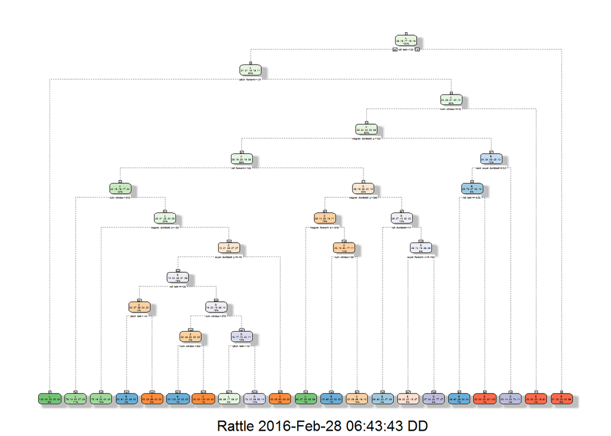

```r
predictionsSet1 <- predict(modFitSet1, subsettrain, type = "class")
confusionMatrix(predictionsSet1, subsettrain$classe)
```

```
## Confusion Matrix and Statistics
##
##           Reference
## Prediction    A    B    C    D    E
##          A 3255  538   82  172   55
##          B   93 1384   77   59   51
##          C   37  172 1800  314  194
##          D  197  243  121 1359  262
##          E   45  132  145  187 1783
##
## Overall Statistics
##
##                Accuracy : 0.751
##                  95% CI : (0.7434, 0.7585)
##     No Information Rate : 0.2843
##     P-Value [Acc > NIR] : < 2.2e-16
##
##                   Kappa : 0.684
##  Mcnemar's Test P-Value : < 2.2e-16
##
## Statistics by Class:
##
##                      Class: A Class: B Class: C Class: D Class: E
## Sensitivity            0.8974   0.5606   0.8090   0.6499   0.7603
## Specificity            0.9072   0.9728   0.9319   0.9228   0.9511
## Pos Pred Value         0.7935   0.8317   0.7151   0.6228   0.7779
## Neg Pred Value         0.9570   0.9022   0.9585   0.9308   0.9463
## Prevalence             0.2843   0.1935   0.1744   0.1639   0.1838
## Detection Rate         0.2552   0.1085   0.1411   0.1065   0.1398
## Detection Prevalence   0.3215   0.1304   0.1973   0.1710   0.1797
## Balanced Accuracy      0.9023   0.7667   0.8705   0.7864   0.8557
```

Random Forest Tree Machine language Algorithm

```
## Confusion Matrix and Statistics
##
##           Reference
## Prediction    A    B    C    D    E
##          A 3627    0    0    0    0
##          B    0 2469    0    0    0
##          C    0    0 2225    0    0
##          D    0    0    0 2091    0
##          E    0    0    0    0 2345
##
## Overall Statistics
##
##                Accuracy : 1
##                  95% CI : (0.9997, 1)
##     No Information Rate : 0.2843
##     P-Value [Acc > NIR] : < 2.2e-16
##
##                   Kappa : 1
##  Mcnemar's Test P-Value : NA
##
## Statistics by Class:
##
##                      Class: A Class: B Class: C Class: D Class: E
## Sensitivity            1.0000   1.0000   1.0000   1.0000   1.0000
## Specificity            1.0000   1.0000   1.0000   1.0000   1.0000
## Pos Pred Value         1.0000   1.0000   1.0000   1.0000   1.0000
## Neg Pred Value         1.0000   1.0000   1.0000   1.0000   1.0000
## Prevalence             0.2843   0.1935   0.1744   0.1639   0.1838
## Detection Rate         0.2843   0.1935   0.1744   0.1639   0.1838
## Detection Prevalence   0.2843   0.1935   0.1744   0.1639   0.1838
## Balanced Accuracy      1.0000   1.0000   1.0000   1.0000   1.0000
```

Evaluation of subset of training test data, lets go with “RF” since it has good accuracy.

```
## Confusion Matrix and Statistics
##
##           Reference
## Prediction    A    B    C    D    E
##          A 1953    2    0    0    0
##          B    0 1325    0    0    0
##          C    0    1 1197    8    0
##          D    0    0    0 1117    9
##          E    0    0    0    0 1253
##
## Overall Statistics
##
##                Accuracy : 0.9971
##                  95% CI : (0.9955, 0.9982)
##     No Information Rate : 0.2845
##     P-Value [Acc > NIR] : < 2.2e-16
##
##                   Kappa : 0.9963
##  Mcnemar's Test P-Value : NA
##
## Statistics by Class:
##
##                      Class: A Class: B Class: C Class: D Class: E
## Sensitivity            1.0000   0.9977   1.0000   0.9929   0.9929
## Specificity            0.9996   1.0000   0.9984   0.9984   1.0000
## Pos Pred Value         0.9990   1.0000   0.9925   0.9920   1.0000
## Neg Pred Value         1.0000   0.9995   1.0000   0.9986   0.9984
## Prevalence             0.2845   0.1934   0.1744   0.1639   0.1838
## Detection Rate         0.2845   0.1930   0.1744   0.1627   0.1825
## Detection Prevalence   0.2848   0.1930   0.1757   0.1640   0.1825
## Balanced Accuracy      0.9998   0.9989   0.9992   0.9957   0.9964
```

Lets predict the category of the test data using the Random Forest model we built.

```
##  1  2  3  4  5  6  7  8  9 10 11 12 13 14 15 16 17 18 19 20
##  B  A  B  A  A  E  D  B  A  A  B  C  B  A  E  E  A  B  B  B
## Levels: A B C D E
```